# Group 2 Second Markdown Project:

Monty Hall and the 6/58 Lotto

Raphael Lee, Javier Bolong, Allen Able, Tricia Pulmano

2021-07-16

# The Monty Hall Problem: What is it?

[figure not shown]

The Monty Hall problem comes from the game show called “Let’s make a Deal.”

That popular game show from the 70’s

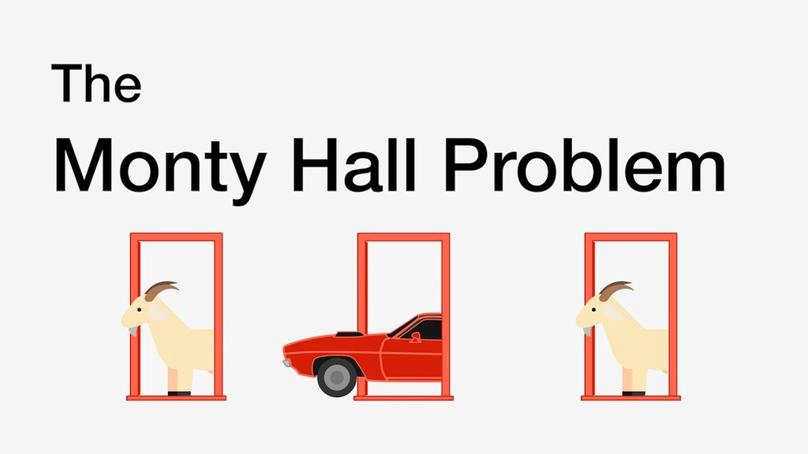

A contestant is given 3 doors to pick from, one of which has a car behind it as the grand prize. The other two doors are duds, containing items that aren’t desirable.

In this case, the dud item is a goat. Goats aren’t so bad…

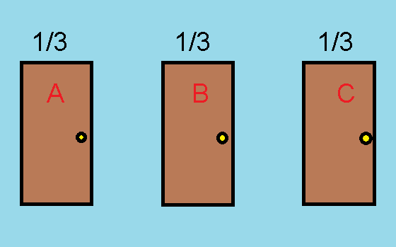

The three doors

When picking a door normally, the chances of winning a car are

$$\frac{1}{3}$$

since there are three doors in total, and you pick one.

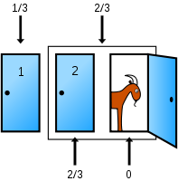

But that means that the other two doors have a
$$\frac{2}{3}$$
chance of winning the grand prize.

Then, the host would open one of the dud doors and ask the contestant whether he/she wants to switch. Since probability isn’t subtracted when that door is open, that means that the remaining door has a 2/3 chance of winning the car, since the remaining probability falls on that lone door.

The odds are in your favor, if you switch

The total probability can never equal to less than 1, since 1 represents 100%.

$$\frac{1}{3}+\frac{2}{3}=1$$

The unique thing about the Monty Hall problem is that because of this probability phenomenon, the best choice would be to switch doors because of the higher probability.

This problem plays with your mind because you start to doubt your choice. As you pick a door, you might be uncertain of its outcome, yet you also are left to ponder on whether you have already picked the best case scenario.

The opening of the dud door and the question of switching your choice at the last minute presents you new information, and makes people unsure of whether they should go with their choice or make the switch. Though in the long term, making the switch is far more effective.

I think its a good way to spice up normal game shows because it plays with the mind and shows the concepts of probability.

# The famous 6/58 Lotto

[figure not shown]

Lotto 6/58

The 6/58 lotto is a pretty famous Lotto known by many Filipinos. The name 6/58 comes from how the lotto is played. One picks 6 numbers from 1 to 58. If the numbers are the same as the winning numbers, in any order, then the person gets the jackpot.

To know how much a bettor would spend, the number of possible of combinations must be computed using the formula

$$\frac{n!}{[r!(n-r!)]}=nCr.$$

Since the number of numbers to choose from in the Ultra lotto is 58, then the value of n = 58. Meanwhile, the number of numbers to pick is 6 per ticket, so r = 6.

The possible number of combinations is then:
$$58C6=\frac{58!}{[6!(52!)]}=40,475,358.$$

Since each ticket costs P20, the better would have to spend
$$40,475,358(20) = P809,507,160.$$
to cover all of the possible combinations.

Thinking about the massive scale of the lotto, it’s a surprisingly effective business model.

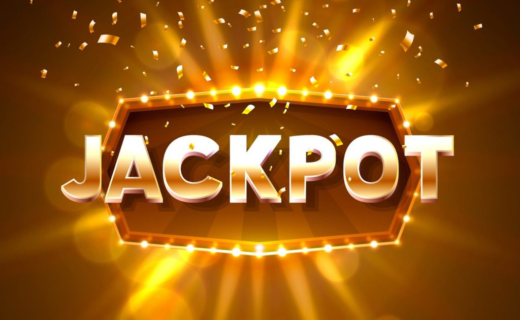

This means that the grand prize of P50 million would not cover all the expenses spent in covering all combinations since 50 million is far less than 800 million.